# Correlates of Birth Defects in Texan Counties

Aidan Isaac, American University ai2401a@american.edu

## Introduction and Methods

In this project, I sought to find out statistically significant factors that may increase birth defects. I chose Texas for this project as the Texas Department of State Health Services (DSHS) keeps robust, detailed, and accurate data regarding birth defects in the entire state. In the period from 2012-2021, Texas recorded 377,000 birth defects[<sup>1</sup>](https://www.dshs.texas.gov/texas-birth-defects-epidemiology-surveillance/birth-defects-data-publications), far exceeding the data kept from other states in the US. The definition of birth defect according to the Texas DSHS is any abnormality that is present at birth. I started out by compiling county level data from the DSHS from 2012-2021[<sup>2</sup>](https://healthdata.dshs.texas.gov/dashboard/births-and-deaths/birth-defects#data-source). I then used the CDC’s 2019 County Health data for other variables, such as binge drinking rates[<sup>3</sup>](https://www.countyhealthrankings.org/health-data/community-conditions/health-infrastructure/health-promotion-and-harm-reduction/excessive-drinking?year=2019&state=48&tab=1), air pollution levels[<sup>4</sup>](https://www.countyhealthrankings.org/health-data/texas/data-and-resources), and diabetes rates[<sup>5</sup>](https://www.countyhealthrankings.org/health-data/texas/data-and-resources). All of those rates are from 2019, which I chose as it was the last year before the COVID-19 pandemic. My initial research focused on binge drinking, but I will now focus more heavily on air pollution, as it is the largest contributing factor to birth defects found in the data. Note: Counties with less than 13 recorded counts of birth defects are suppressed, and not available in the dataset.

- Binge drinking is defined by the CDC as over 4 drinks on one occasion, over 8 drinks per week, or drinking at all during pregnancy.
- Air pollution is measured by the CDC as micrograms of particulate matter present per cubic meter.
- Below the Poverty Line is measured by the % of the population making less than $29,000 a year.
- Diabetes is measured by percent of the population diagnosed with Type 1 or Type 2 diabetes.

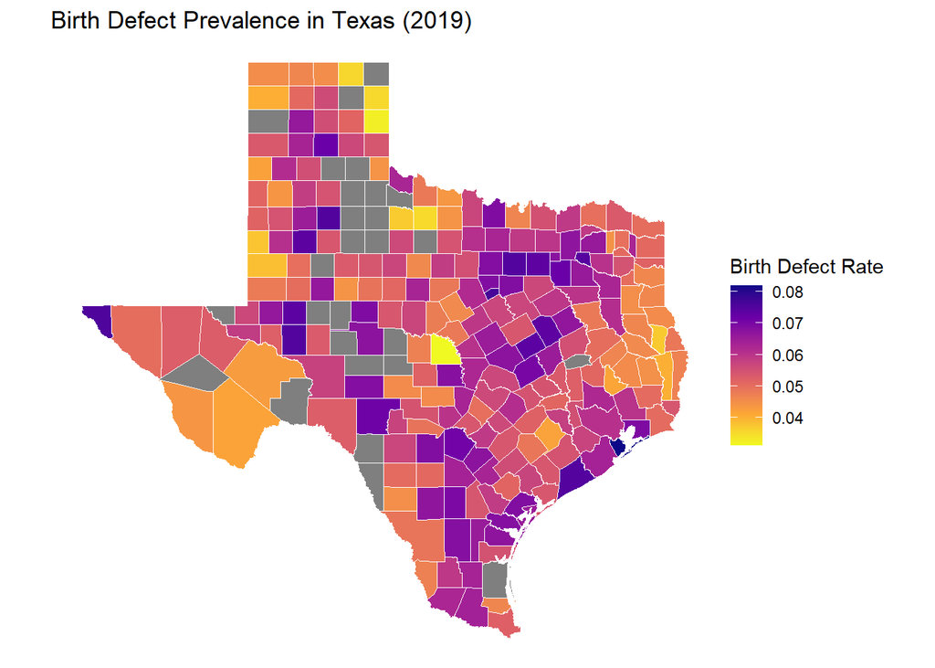

## Hypothesis

Adults who binge drink at a high rate are more likely to have children with birth defects across Texas, and this should be more significant than other factors such as air pollution and diabetes. This hypothesis stemmed from the fact that women are heavily discouraged from drinking alcohol while pregnant, as the existence of birth defects such as Fetal Alcohol Syndrome originate from alcohol consumption while pregnant. I am including air pollution and diabetes in this analysis, as those factors are often cited along with binge drinking by the CDC as contributing to birth defects.

## Graphs and Data

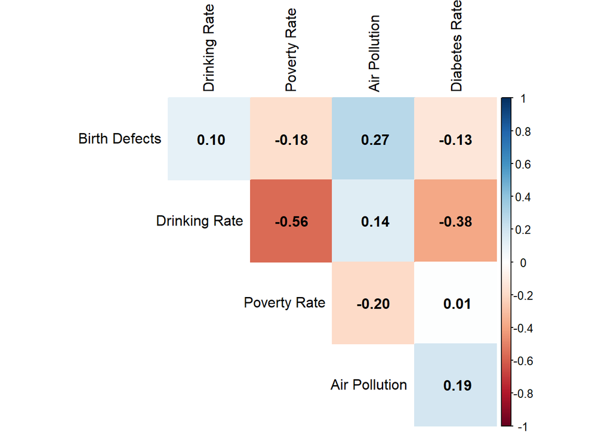

Here is a correlation matrix that I thought was interesting. While not presenting critical information to the research, it shows that correlation rates can be slightly different than what the multiple linear regression model shows. In particular, there’s a very small correlation between birth defects and drinking rates, and a larger one between air pollution and birth defects. Poverty and drinking rates have a high negative correlation, but that is generally irrelevant to the project.

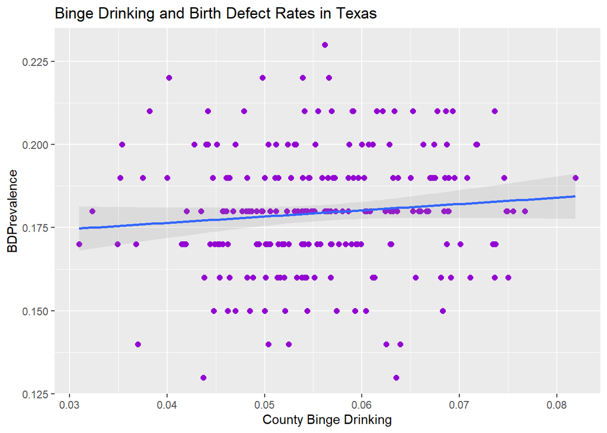

This graph shows a very noisy scatterplot of birth defects and county drinking. It shows that there’s not a strong correlation or statistical significance to the issue.

[figure not shown]

On the contrary, this air pollution scatterplot is still a little noisy, but shows a clear relationship between air pollution and birth defects.

## Results

Table 1: Linear Regression of Birth Defect Prevalence in Texas Counties

| Variable | Coefficient | Std. Error | t-value | p-value |
| --- | --- | --- | --- | --- |
| Intercept | 0.07213 | 0.01286 | 5.610 | < 0.001*** |
| County Drinking Rate (%) | -0.07576 | 0.04590 | -1.651 | 0.1 |
| Below Poverty Line (%) | -0.00023 | 0.00009 | -2.479 | 0.014* |
| Air Pollution Level (µg/m³) | 0.00222 | 0.00049 | 4.536 | < 0.001*** |
| Diabetes Prevalence (%) | -0.00151 | 0.00045 | -3.328 | 0.001** |

This table shows a multiple linear regression model of birth defect prevalence in Texas counties with county drinking rates, percent of people below the poverty level, air pollution levels, and diabetes prevalence.

## Conclusion and Findings

Analyzing the Impacts of Air Pollution on Birth Defects in Texas

[figure not shown]